# September 2023 BikeShare Data Analysis

Naida Torres

2023-11-06

Today, we will focus on September 2023 bikeshare data.

```r
library(here)
library(janitor)
library(tidyverse)
library(openmeteo)
library(ggplot2)
library(plotly)
library(tmap)
library(sf)
```

Now, we will load the data.

```r
df1 = read_csv(here("data_raw",
                    "202309-capitalbikeshare-tripdata.zip"))
```

```
Multiple files in zip: reading '202309-capitalbikeshare-tripdata.csv'Rows: 450090 Columns: 13── Column specification ───────────────────────────────────────────────────────────────────────────────────
```

Extract some data into data frames for starting information.

```r
df2s = df1 %>%
  select(rideable_type,
         member_casual,
         contains("start"),
         ride_id) %>%
  mutate(start_stop = "start") %>%
  rename(t = started_at,
         station_name = start_station_name,
         station_id = start_station_id,
         lat = start_lat,
         lng = start_lng)

df2e = df1 %>%
  select(ride_id,
         rideable_type,
         member_casual,
         contains("end")) %>%
  mutate(start_stop = "stop") %>%
  rename(t = ended_at,
         station_name = end_station_name,
         station_id = end_station_id,
         lat = end_lat,
         lng = end_lng)

df2 = bind_rows(df2s,
                df2e) %>%
  arrange(t) %>%
  mutate(rider_delta = (start_stop == "start") * 2 - 1) %>% # change in ridership
  mutate(riders = cumsum(rider_delta)) %>%
  relocate(riders, .after = t)
```

Making df2.

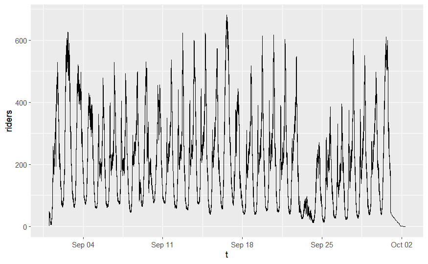

```r
df2 %>%
  ggplot(aes(t, riders)) +
  geom_line()
```

# Constructing a subsampled dataset

We work with a small slice of data as we build the approach, as it is computationally efficient.

```r
df_s = df2 %>%
  slice_head(n = 1000)
```

We can round-down (floor) to the nearest 10 minute point, and then sample the first (earliest) point within that 10 minute window.

```r
df_e = df_s |>
  mutate(t_f = floor_date(t,
                          "10 mins")) %>%
  relocate(t_f,
           .after = t) %>%
  slice_head(n = 1,
             by = t_f)
```

The procedure seems reasonable so we apply to full data set and visualize.

```r
df_r = df2 |>
  mutate(t_f = floor_date(t,
                          "10 mins")) %>%
  relocate(t_f,
           .after = t) %>%
  slice_head(n = 1,
             by = t_f)
```

We plot the original data.

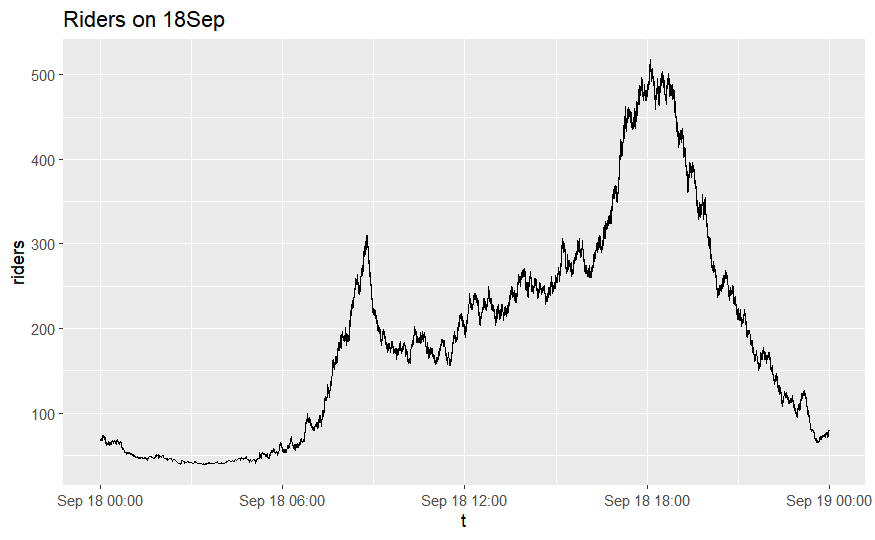

```r
p1 = df2 %>%
  filter(day(t) == 18) %>%
  ggplot(aes(t,
             riders)) +
  geom_line() +
  ggtitle("Riders on 18Sep")
p1
```

We plot for the 18th, and compare to our original visualization.

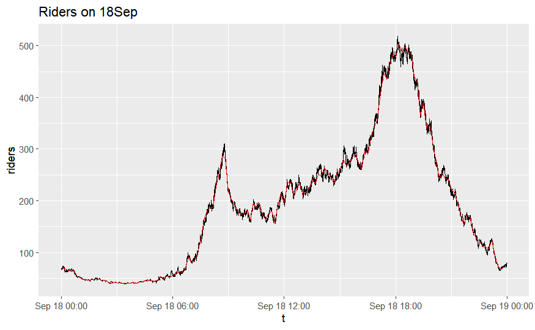

```r
p1+
  geom_line(data = df_r %>%
              filter(day(t) == 18),
            color = "red")
```

Based on figure above, it seems like subsampling based on nearest minute may be more appropriate:

```r
df_r = df2 |>
  mutate(t_f = floor_date(t,
                          "1 mins")) %>%
  relocate(t_f,
           .after = t) %>%
  slice_head(n = 1,
             by = t_f)
```

We re-plot for the 18th, and compare to our original visualization.

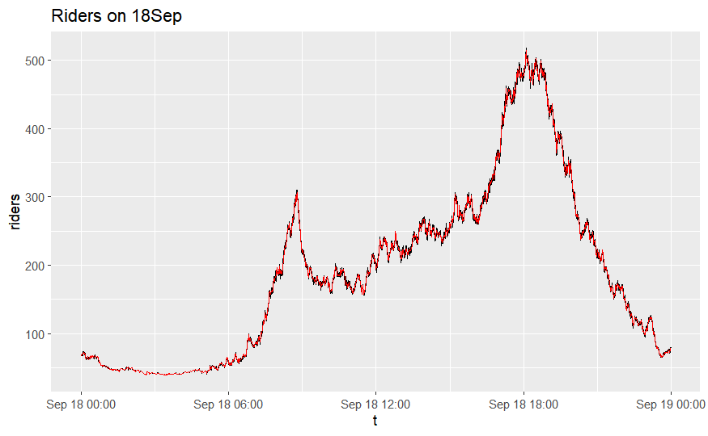

```r
p1+
  geom_line(data = df_r %>%
              filter(day(t) == 18),
            color = "red")
```

We will get the weather history for Washington in September.

```r
df_w = weather_history("Washington",
                       start = "2023-09-01",
                       end = "2023-09-30",
                       hourly = c("apparent_temperature",
                                  "wind_speed_10m",
                                  "precipitation"))
```

```
`geocode()` has matched "Washington" to:
Washington in Washington, D.C., United States
Population: 601723
Co-ordinates: c(38.89511, -77.03637)
```

We work with a small slice of data as we build the approach, as it is computationally efficient.

```r
df_s = df2 %>%
  slice_sample(n = 1000)
```

```r
df_j = df_s %>%
  left_join(df_w,
            by = join_by(closest(t >= datetime)))
```

Normally, joined columns are added to the right. Let’s move the data time column (for the weather forecast, next to ‘t’) and examine where we stand.

```r
df_j = df_s %>%
  left_join(df_w,
            by = join_by(closest(t >= datetime))) %>%
  relocate(datetime,
           .after = t)

head(df_j)
```

| rideable_type | member_casual | t | datetime | riders | station_name | station_id | lat | lng | ride_id | start_stop | rider_delta | hourly_apparent_temperature | hourly_wind_speed_10m | hourly_precipitation |
| --- | --- | --- | --- | --- | --- | --- | --- | --- | --- | --- | --- | --- | --- | --- |
| classic_bike | member | 2023-09-08 21:17:16 | 2023-09-08 17:00:00 | 234 | New Hampshire Ave & T St NW | 31229 | 38.91554 | -77.03825 | 18892EB233E48AB0 | start | 1 | 34.4 | 7.6 | 0.0 |
| classic_bike | casual | 2023-09-03 11:02:00 | 2023-09-03 07:00:00 | 388 | Jefferson Dr & 14th St SW | 31247 | 38.88855 | -77.03243 | 21211D0A869BDC75 | start | 1 | 23.2 | 5.9 | 0.0 |
| classic_bike | member | 2023-09-20 17:15:55 | 2023-09-20 13:00:00 | 534 | 14th St & Colorado Ave NW | 31407 | 38.95643 | -77.03295 | 184583941B4FD0EF | start | 1 | 25.3 | 1.5 | 0.0 |
| classic_bike | member | 2023-09-16 17:27:45 | 2023-09-16 13:00:00 | 605 | Eastern Market / 7th & North Carolina Ave SE | 31610 | 38.88695 | -76.99681 | A82DC797E422B5AE | start | 1 | 26.0 | 9.2 | 0.0 |
| classic_bike | member | 2023-09-22 08:23:05 | 2023-09-22 04:00:00 | 236 | 17th & Corcoran St NW | 31214 | 38.91210 | -77.03870 | D265E63D40A5924F | start | 1 | 15.6 | 8.5 | 0.0 |
| electric_bike | member | 2023-09-26 09:50:11 | 2023-09-26 05:00:00 | 121 | 22nd & I St NW / Foggy Bottom | 31257 | 38.90088 | -77.04891 | BE2CCFA22AFC1EBF | stop | -1 | 14.7 | 12.9 | 0.2 |

NOTE: Our times don’t match up.

```r
df_j$t[1:5]
```

```
[1] "2023-09-08 21:17:16 UTC" "2023-09-03 11:02:00 UTC" "2023-09-20 17:15:55 UTC" "2023-09-16 17:27:45 UTC"
[5] "2023-09-22 08:23:05 UTC"
```

```r
df_j$datetime[1:5]
```

```
[1] "2023-09-08 17:00:00 EDT" "2023-09-03 07:00:00 EDT" "2023-09-20 13:00:00 EDT" "2023-09-16 13:00:00 EDT"
[5] "2023-09-22 04:00:00 EDT"
```

GOAL: Make time zones match up.

```r
df2$t[1:5]
```

```
[1] "2023-09-01 00:00:44 UTC" "2023-09-01 00:01:48 UTC" "2023-09-01 00:01:48 UTC" "2023-09-01 00:02:03 UTC"
[5] "2023-09-01 00:02:21 UTC"
```

```r
force_tz(df2$t[1:5],
         "America/New_York")
```

```
[1] "2023-09-01 00:00:44 EDT" "2023-09-01 00:01:48 EDT" "2023-09-01 00:01:48 EDT" "2023-09-01 00:02:03 EDT"
[5] "2023-09-01 00:02:21 EDT"
```

```r
df2c = df2 %>%
  mutate(t = force_tz(t,
                      tzone = "America/New_York")) # Corrected

df_s2 = df2c %>%
  slice_sample(n = 1000)

df_j2 = df_s2 %>%
  left_join(df_w,
            by = join_by(closest(t >= datetime)))  %>%
  relocate(datetime,
           .after = t)

head(df_j2)
```

| rideable_type | member_casual | t | datetime | riders | station_name | station_id | lat | lng | ride_id | start_stop | rider_delta | hourly_apparent_temperature | hourly_wind_speed_10m | hourly_precipitation |
| --- | --- | --- | --- | --- | --- | --- | --- | --- | --- | --- | --- | --- | --- | --- |
| electric_bike | member | 2023-09-28 22:29:32 | 2023-09-28 22:00:00 | 166 | Columbia Rd & Belmont St NW | 31113 | 38.92072 | -77.04375 | 6B7E34C5F4B704A2 | start | 1 | 16.6 | 10.9 | 0.0 |
| classic_bike | casual | 2023-09-04 04:17:39 | 2023-09-04 04:00:00 | 73 | 15th St & N Scott St | 31031 | 38.89054 | -77.08095 | 9C2EEED4F925A164 | start | 1 | 26.9 | 9.2 | 0.0 |
| classic_bike | member | 2023-09-12 12:55:08 | 2023-09-12 12:00:00 | 254 | 1st & K St NE | 31662 | 38.90239 | -77.00565 | 4DE10DE2277AA8E3 | stop | -1 | 32.6 | 3.0 | 0.0 |
| electric_bike | casual | 2023-09-28 08:18:25 | 2023-09-28 08:00:00 | 274 | 22nd St & Constitution Ave NW | 31292 | 38.89244 | -77.04895 | 0B1B29EE34E77729 | stop | -1 | 13.9 | 10.0 | 0.0 |
| electric_bike | member | 2023-09-08 20:46:44 | 2023-09-08 20:00:00 | 227 | Oklahoma Ave & D St NE | 31712 | 38.89442 | -76.97490 | 176EA0A2506F1FCE | start | 1 | 26.9 | 5.3 | 5.4 |
| classic_bike | member | 2023-09-28 19:17:09 | 2023-09-28 19:00:00 | 399 | 17th & Corcoran St NW | 31214 | 38.91210 | -77.03870 | 77673A6AA9D730B5 | stop | -1 | 17.6 | 12.4 | 0.0 |

Now that we have built our methodology, lets create the joined data set in the right way.

Also, for convenience, lets change our variable names in the weather data to be a bit shorter.

```r
dfc = df2c %>%
  left_join(df_w, by = join_by(closest(t >= datetime))) %>%
  relocate(datetime,
           .after = t) %>%
  rename (atemp = hourly_apparent_temperature,
          wind = hourly_wind_speed_10m,
          prec = hourly_precipitation)
```

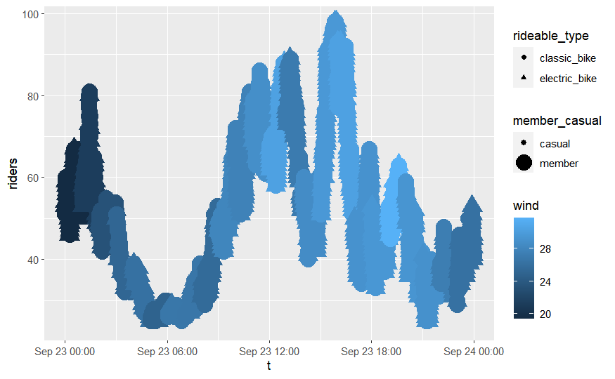

```r
df_r = dfc |>
  mutate(t_f = floor_date(t,
                          "10 mins")) %>%
  relocate(t_f,
           .after = t) %>%
  slice_head(n = 1,
             by = t_f)

p2 = dfc %>%
  filter (day(t) == 23) %>%
  ggplot(aes(x = t,
             riders,
             color = wind,
             shape = rideable_type,
             size = member_casual)) +
  geom_point()
p2
```

```r
plotly::ggplotly(p2)
```

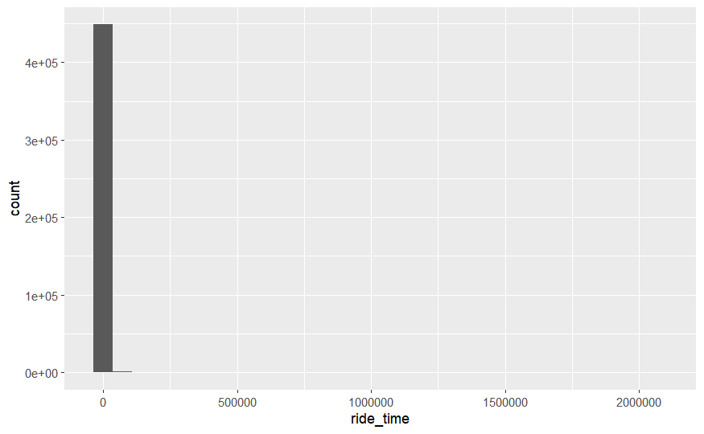

```r
df1d = df1 %>%
  mutate(ride_time = ended_at - started_at)

df1d %>%
  ggplot(aes(ride_time)) +
  geom_histogram()
```

```r
neigh = st_read(here("data_raw",
                     "DC_Health_Planning_Neighborhoods.geojson")) %>%
  clean_names()
class(neigh)
```

```
[1] "sf"         "data.frame"
```

```r
map_and_data <- innerjoin(neigh, dfc, by = c ("NAME"))
```

```
Error in innerjoin(neigh, dfc, by = c("NAME")) :
  could not find function "innerjoin"
```